# pH in the Poudre

# Background

This week’s content covers acid base chemistry, so to tie that work to real data we will be working with pH and chemistry data from the Poudre River.

## Why work in R?

This assignment shows an example where working with R can really make the work go faster, be more beautiful, and have a bigger impact on our audience.

### Downloading data

If you haven’t worked with usgs data before then what you need to is that each USGS station (where they measure discharge and other water parameters like pH) has a unique siteID code. Each possible measurement also has a unique parameter code. So we will need this info here

Site ID = `06752260` Parameter Code for pH = `00400` Parameter Code for Q (discharge) = `00060` startDate = `1989-01-01` endDate = `1999-12-31`

```r
# Download pH data and rename the columns
ph <- readNWISdata(siteNumbers = '06752260',
                 startDate = '1989-01-01',
                 endDate = '1999-12-31',
                 parameterCd = '00400') %>%
  select(dateTime,ph = X_00400_00002)


#Download Discharge data for same period
q <- readNWISdata(siteNumbers = '06752260',
                 startDate = '1989-01-01',
                 endDate = '1999-12-31',
                 parameterCd = '00060') %>%
  select(dateTime,q_cfs = X_00060_00003)
```

### Exploring the data

Now that we have downloaded both river discharge and pH time series we may want to take a look at these data.

A few useful functions for looking at data are: `View`, `head`, and `str`

#### View

```r
## Your code Here

# View(ph)
```

#### head

```r
head(ph)
```

```
FALSE     dateTime  ph
FALSE 1 1989-03-22 7.8
FALSE 2 1989-03-23 7.8
FALSE 3 1989-03-24 7.8
FALSE 4 1989-03-25 7.7
FALSE 5 1989-03-26 7.8
FALSE 6 1989-03-27 7.8
```

#### str (Structure)

Ctrl + Alt + I

```r
str(q)
```

```
FALSE 'data.frame': 4017 obs. of  2 variables:
FALSE  $ dateTime: POSIXct, format: "1989-01-01" "1989-01-02" ...
FALSE  $ q_cfs   : num  2.6 2.8 4.3 5.4 4.7 4.1 3.9 3.5 3 3.2 ...
```

### Plotting the data

#### Static Plot

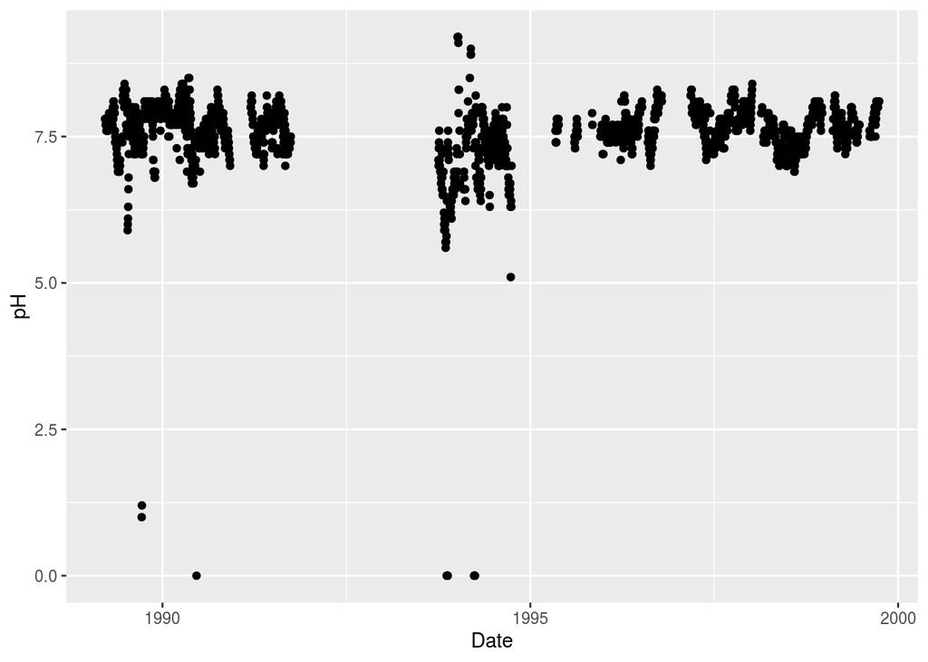

```r
ggplot(ph, aes(x = dateTime, y = ph)) +
  geom_point() +
  xlab('Date') +
  ylab('pH')
```

#### Dynamic plot

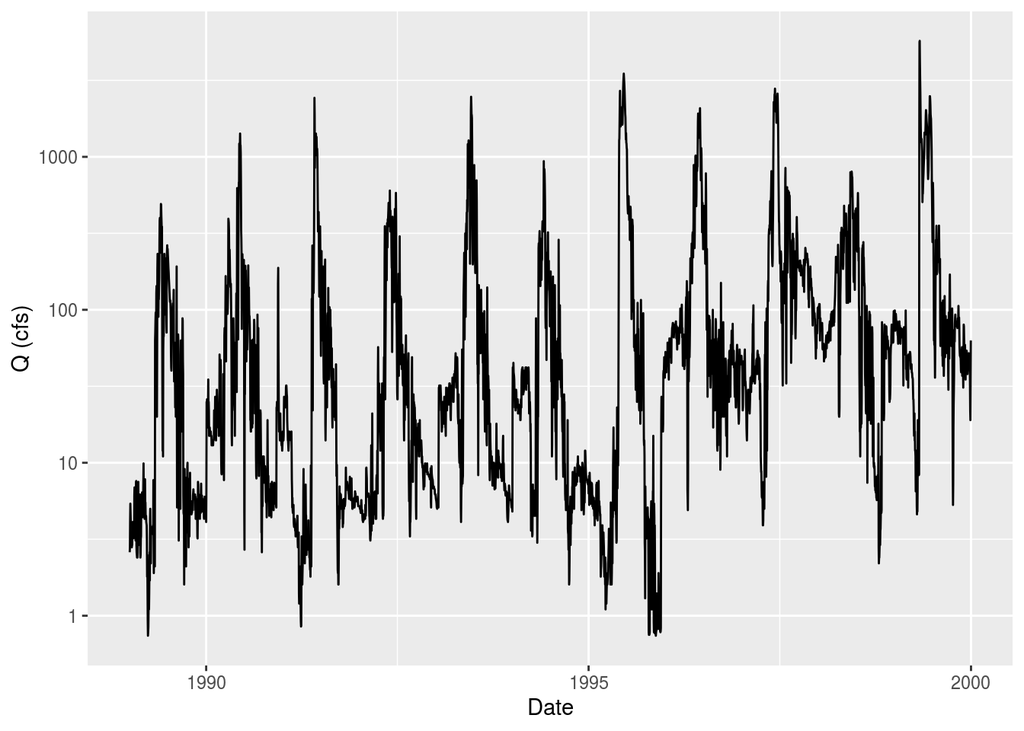

```r
ggplot(q, aes(x = dateTime, y = q_cfs)) +
  geom_line() +
  scale_y_log10() +
  xlab('Date') +
  ylab('Q (cfs)')
```

```r
q_ts <- xts(q$q_cfs, order.by = q$dateTime)

dygraph(q_ts)
```

[interactive chart not shown]

# Assignment

Now we will use the data we just downloaded and manipulated to explore how pH varies in the Poudre and what might control pH.

## Q1 - Controls on pH

#### Joining the data

```r
# Joining Q and pH data to make a single data frame
qph <- left_join(q, ph, by = 'dateTime')

qph_clean <- filter(qph, ph > 2.5)
```

## Q3 Make a bonus plot

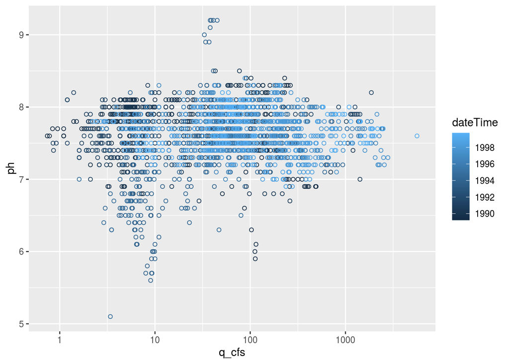

```r
ggplot(qph_clean, aes(x=q_cfs, y = ph, color = dateTime)) +
  geom_point(shape = 1) +
  scale_x_log10()
```